# 8.1 Media poblacional: $\sigma$ conocida

# 8.4 Proporcion poblacional

Hasta el momento conosemso la formula general para obtener una estimacion por intervalo de la proporcion poblacional P: $$ \bar{p} \pm \text{margen de error} $ $$

La manera en que las muestras son seleccionadas influye directamente en la precisión de las estimaciones por intervalo de una proporción p. La variabilidad en estas muestras juega un papel clave al determinar cuán seguros podemos estar sobre la verdadera proporción en la población general. En el capítulo 7 se ha mencionado que la distribución de muestreo de p se aproxima mediante una distribución normal siempre que: $$ np \geq 5 \quad \text{y} \quad n(1-p) \geq 5 $$

Figura 8.9 Aproximación normal a la distribución de muestreo de $\bar{p}$

```python
import numpy as np
import matplotlib.pyplot as plt
import scipy.stats as stats

# Nivel de significancia
alfa = 0.05

# Generar datos para la distribución normal estándar (z)
x = np.linspace(-4, 4, 1000)
y = stats.norm.pdf(x)

# Encontrar el valor crítico para el nivel de significancia alfa/2
valor_critico = stats.norm.ppf(1 - alfa/2)

# Crear el gráfico con la línea de color verde y etiqueta con el símbolo mu (μ)
plt.figure(figsize=(9, 4))
plt.plot(x, y, label=r'Distribución Normal Estándar ($\mu$)', color='green')  # Cambié el color a verde y añadí el símbolo mu

# Sombrear el área debajo de la línea con un verde más oscuro
plt.fill_between(x, y, color='#5CCB5F', alpha=0.3)

# Etiqueta de texto 1: Distribución de muestreo de x̄
plt.text(-4, 0.20, 'Distribución de muestreo\n   de $\\bar{p}$', ha='left')

# Etiqueta de texto 2: σ/√n
plt.text(3, 0.20, r'$\sigma_\bar{p} = \sqrt{\frac{p(1 - p)}{n}}$', fontsize=12, ha='right')

# Establecer el color de fondo
plt.gca().set_facecolor('#d4f8b7')

plt.text(-2.5, 0.04, '${α/2}$', ha='left')

plt.text(2.5, 0.04, '${α/2}$', ha='left')

plt.text(-1.5, 0.01, '<--$z_{α/2}$-->', ha='left')
plt.text(0.8, 0.01, '<--$z_{α/2}$-->', ha='left')

# Mostrar el gráfico
plt.grid(False)
plt.show()
```

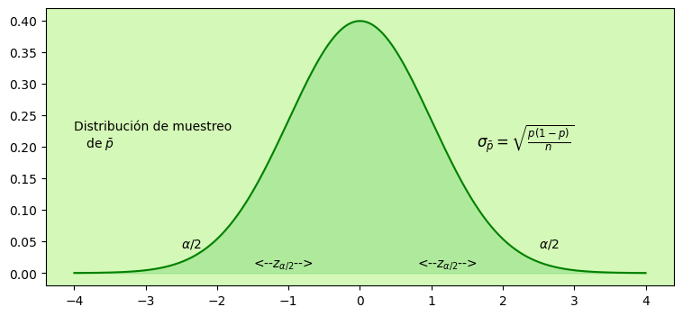

La media de la distribución de muestreo de \( p \) es la proporción poblacional \( p \), y el error estándar de \( p \) es:

$$ \begin{equation} \sigma_\bar{p} = \sqrt{\frac{p(1 - p)}{n}} \tag{8.4} \end{equation} $$

Como la distribución de muestreo de \(\bar{p}\) es una distribución normal, en la estimación por intervalo de la proporción poblacional se elige como margen de error \(z_{\alpha/2} \cdot \sigma_{\bar{p}}\). Entonces, \( 100(1-\alpha)\% \) de los intervalos que se obtengan contendrán la verdadera proporción poblacional. Sin embargo, para calcular el margen de error, no podemos usar directamente \(\sigma_{\bar{p}}\) ya que no se conoce \(p\), puesto que se trata de estimarlo. Lo que se hace es que \(p\) se sustituye por \(\bar{p}\) y de esta manera, el margen de error es dado por:

$$ \begin{equation} \text{Margen de error} = z_{\alpha/2} \cdot \sqrt{\frac{\bar{p}(1-\bar{p})}{n}} \tag{8.5} \end{equation} $$

**ESTIMACION POR INTERVALO DE UNA PROPORCION POBLACIONAL**

$$ \begin{equation} \bar{p} \pm z_{\alpha/2} \cdot \sqrt{\frac{\bar{p}(1-\bar{p})}{n}} \tag{8.6} \end{equation} $$

### EJEMPLO:

Un estudio en Bolivia encuestó a $900$ mujeres futbolistas para conocer su opinión acerca de como se les trata en los cursos de futbol, en este estudio se encontro que $396$ estaban satisfechas con la disponibilidad de horarios de salida. Por tanto la estamacion puntual de la proporcion poblacional de futbolistas satisfechas con la disponibilidad de horarios de salida es de $396/900 = 0.44$. Utilizando la expresion $\text(8.5)$ y la $\text(8.6)$ junto al nivel de confianza es de $95$%, calcular el margen de error y la estimación por intervalo para una proporción poblacional.

$$ \begin{equation} \text{Margen de error} = z_{\alpha/2} \cdot \sqrt{\frac{\bar{p}(1-\bar{p})}{n}} \tag{8.5} \end{equation} $$

$$ \begin{equation} \text{Margen de error} = 1.96 \cdot \sqrt{\frac{{0.44}(1-0.44)}{n}} \end{equation} $$

$$ \begin{equation} \text{Margen de error} = 0.0324 \end{equation} $$

Y ahora con la expresion $\text(8.6)$ y reemplazando la proporcion poblacional $0.44$ tenemos:

$$ \begin{equation} \bar{p} \pm 0.0324 \end{equation} $$

$$ \begin{equation} \ 0.44 \pm 0.0324 \end{equation} $$

Empleando porcentajes, los resultados de la investigacion permiten decir que con un $95$ % de confianza que entre $40.76$ % y $47.24$ % de las mujeres futbolistas estan satisfechas con la disponibilidad de horarios de salida.

# Determinacion del tamaño de la muestra

Al determinar el tamaño de la muestra para estimar la proporción de una población con cierta precisión, se utiliza una función similar a la empleada en la estimación de la media poblacional. La fórmula para determinar el tamaño de la muestra se asemeja a la utilizada en la estimación de la media poblacional en la formula $\text(8.3)$.

Este margen se basa en el valor de $z_{\alpha/2}$ en la proporcion muestral de $\bar{p}$ y en el tamaño de la muestra $n$.

NOTA: Muestras mayores, márgenes de error menores y con mejor precisión.

Sea $E$ el margen de error deseado:

$$ \begin{equation} \text{E} = z_{\alpha/2} \cdot \sqrt{\frac{\bar{p}(1-\bar{p})}{n}} \end{equation} $$

Si despejamos $n$ de esta formula, obtenemos el tamaño de la muestra para obtener el margen de error deseado $E$ y esta dada por:

$$ \begin{equation} \text{$n$} = \frac{(z_{\alpha/2})^2\bar{p}(1-\bar{p})}{E^2} \end{equation} $$

Sin embargo, si no se conoce $\bar{p}$, no es posible usar esta fórmula para calcular el tamaño de la muestra con el que se obtendrá $E$.

Entonces necesitaremos un valor planeado de $\bar{p}$, con $p^*$ como valor planeado de $\bar{p}$, la formula queda:

**TAMAÑO DE LA MUESTAR PARA UNA ESTIMACIÓN POR INTERVALO DE LA PROPORCIÓN POBLACIONAL**

$$ \begin{equation} \text{$n$} = \frac{(z_{\alpha/2})^2 \cdot {p^*} \cdot (1-{p^*})}{E^2} \tag{8.7} \end{equation} $$

El valor planeado $p^*$ es determinado mediante:

**1.** Se utiliza la proporción poblacional de una muestra previa de las mismas unidades o de unidades similares.  
**2.** Se toma un estudio piloto y se elige una muestra preliminar. La proporción muestral de esta muestra se usa como valor planeado, $p^*$.  
**3.** Se utiliza el criterio o una “mejor aproximación” para el valor de $p^*$.  
**4.** Si no es aplicable ninguna de las alternativas anteriores, se emplea como valor planeado $p^* = 0.50$.

Volviendo al ejemplo, de mujeres futbolistas, spongamos que la empresa desea llevar a cabo otra investigación para determinar la proporcion actual en la poblacion de futbolistas que esta satisfecha con la disponibilidad de horarios de salida. ¿De qué tamaño debe ser la muestra si se desea en la estimacion de la proporcion poblacional un margen de error de $0.025$ a $95$% de confianza?

DATOS:

$E = 0.025$  
$z_{\alpha/2} = 1.96$  
$\bar{p} = 0.44$

Con la ecuacion $(8.7)$ tenemos que:

\begin{equation} \text{$n$} = \frac{(z_{\alpha/2})^2 \cdot {p^*} \cdot (1-{p^*})}{E^2} \end{equation} \begin{equation} \text{$n$} = \frac{(1.96)^2 \cdot {(0.44)} \cdot (1-{0.44})}{(0.025)^2} \end{equation} \begin{equation} \text{$n$} = 1514.5 \end{equation}

Entonces tenemos que, el tamaño de muestra debe ser por lo menos $1514.5$ mujeres futbolistas para satisfacer el margen de error requerido. Redondeando, tenemos que se necesitan $1515$ futbolistas para obtener el margen de error deseado.

**TABLA 8.5** Valores posibles de $p^*(1-p^*)$

|  |  | **$p^*$** | **$p^*$$(1$$- p^*$$)$** |  |  |
| --- | --- | --- | --- | --- | --- |
|  |  | 0.10 | (0.10)(0.90) = 0.09 |  |  |
|  |  | 0.30 | (0.30)(0.70) = 0.21 |  |  |
|  |  | 0.40 | (0.40)(0.60) = 0.24 |  |  |
|  |  | 0.50 | (0.50)(0.50) = 0.25 | <---------- máximo valor de $p^*(1-p^*)$ |  |
|  |  | 0.60 | (0.60)(0.40) = 0.24 |  |  |
|  |  | 0.70 | (0.70)(0.30) = 0.21 |  |  |
|  |  | 0.90 | (0.90)(0.10) = 0.09 |  |  |

Seleccionar $p^* = 0.50$ es una alternativa simple cuando no hay informacion especifica disponible. Esto se debe a que, según la ecuacion $(8.7)$, el tamaño de la muestar es proporcional a $p^*(1-p^*)$. Cuando $p^*(1-p^*)$ es grande, el tamaño de la muestra tambien lo es. Escoger $p^* = 0.50$ garantiza el tamaño de la muestra maxima posible cuando no esta seguro del valor planificado. Esto significa que, incluso si la proporcion muestral difiere del valor planificado, el margen de error sera menor de lo esperado.  
En resumen, al usar $p^* = 0.50$, aseguramos que el tamaño de la muestra sea suficiente para obtener la precision deseada, incluso en situaciones de incertidumbre sobre la proporcion real en la poblacion.

Volviendo otra vez, al ejemplo, si se usa como valor planteado $p^* = 0.50$, el tamaño de muestra que se obtiene es:

\begin{equation} \text{$n$} = \frac{(z_{\alpha/2})^2 \cdot {p^*} \cdot (1-{p^*})}{E^2} \end{equation} \begin{equation} \text{$n$} = \frac{(1.96)^2 \cdot {(0.50)} \cdot (1-{0.50})}{(0.025)^2} \end{equation} \begin{equation} \text{$n$} = 1536.6 \end{equation}

Es decir, una muestra ligeramente mayor: $1537$ mujeres futbolistas.

# 8.5 Un poco mas de conocimiento

### **Glosario**

- **σ Conocida** Este dato se usa para obtener un valor confiable de la desviación estándar poblacional antes de tomar una muestra. Este valor conocido (σ) se emplea en la estimación por intervalo para calcular el margen de error.
- **σ Desconocida** Este es un caso común, para estimar la desviación estándar poblacional antes de tomar la muestra. En la estimación por intervalo se usa la desviación estándar muestral $s$ para calcular el margen de error
- **Coeficiente de confianza** Nivel de confianza expresado como valor decimal.
- **Distribucion $t$** Es una familia de distribuciones utilizada para estimar por intervalo la media poblacional cuando la desviación estándar poblacional no es conocida y se estima con la desviación estándar muestral.
- **Estimación por intervalo** Proporciona un rango que se cree contiene el valor del parámetro, utilizando una fórmula que combina la estimación puntual y el margen de error.
- **Grados de libertad** Son un parámetro esencial. Cuando esta distribución se emplea para realizar una estimación por intervalo de la media poblacional, la distribución t asociada tiene n - 1 grados de libertad, siendo n el tamaño de la muestra aleatoria simple.
- **Margen de error** Es el valor que se suma y resta de la estimación puntual.
- **Nivel de confianza** Asociado con la probabilidad de que el intervalo contenga el parámetro poblacional. Por ejemplo, un nivel de confianza del 95% indica que el 95% de los intervalos estimados contendrán el parámetro.

## **Fórmulas clave**

**Estimación por intervalo de la media poblacional: $\sigma$ conocida**

$$ \begin{equation} \bar{x} \pm z_{α/2} \frac{\sigma}{\sqrt{n}}\tag{8.1} \end{equation} $$

**Estimación por intervalo de la media poblacional: $\sigma$ desconocida**

$$ \begin{equation} \bar{x} \pm t_{α/2} \frac{s}{\sqrt{n}}\tag{8.2} \end{equation} $$

**Tamaño de la muestra para una estimación por intervalo de la media poblacional**

$$ \begin{equation} \text{$n$} = \frac{(z_{\alpha/2})^2\sigma^2}{E^2}\tag{8.3} \end{equation} $$

**Estimación por intervalo de una proporción poblacional**

$$ \begin{equation} \bar{p} \pm z_{\alpha/2} \cdot \sqrt{\frac{\bar{p}(1-\bar{p})}{n}}\tag{8.6} \end{equation} $$

**Tamaño de la muestra para una estimación por intervalo de la proporcion poblacional**

$$ \begin{equation} \text{$n$} = \frac{(z_{\alpha/2})^2 \cdot {p^*} \cdot (1-{p^*})}{E^2}\tag{8.7} \end{equation} $$

# **Estimación por intervalo con Minitab**

A continuación se describe cómo usar Minitab para obtener intervalos de confi anza de la media poblacional y la proporción poblacional

### Media poblacional: σ desconocida

Utilizando una muestra de 70 hogares con datos de saldos en tarjetas de crédito en la columna Cl de una hoja de cálculo en Minitab, se ilustra la estimación por intervalo para la media poblacional. En lugar de la desviación estándar poblacional σ, se estima utilizando la desviación estándar muestral s. Sigue estos pasos:

1. Abre el menú "Stat".
2. Selecciona "Basic Statistics".
3. Escoge "1-Sample t".
4. En el cuadro de diálogo "1-Sample t":
- Ingresa los datos de la muestra en la columna especificada, por ejemplo, C1.
5. Haz clic en "OK".

Por defecto, Minitab usa un nivel de confianza del 95%. Para especificar otro nivel, como 90%, sigue estos pasos adicionales:

1. Después de seleccionar "1-Sample t", selecciona "Options".
2. En el cuadro de diálogo "1-Sample t-Options":
- Ingresa el nivel de confianza deseado, por ejemplo, 90, en el campo de "Confidence level".
3. Haz clic en "OK".

### Proporción poblacional

1. Abre Minitab y selecciona 'Stat'.
2. Escoge 'Basic Statistics'.
3. Selecciona '1 Proportion'.
4. Ingresa los datos de la muestra en la columna indicada (por ejemplo, C1).
5. Selecciona 'Options' y elige 'Use test and interval based on normal distribution'. Haz clic en 'OK'.
6. Obtendrás el intervalo de confianza predeterminado del 95%. Para cambiar el nivel de confianza, como a 90%, ingresa este valor en 'Confidence Level' dentro de 'Options' en el paso 5.

Recuerda: Minitab asume el segundo valor en orden alfabético como la proporción de interés. Si este no es el caso, puedes definir un orden personalizado en Minitab para obtener la respuesta deseada.

```python
from IPython.display import YouTubeVideo
youtube_video = YouTubeVideo('Sf5TvUPp-rc')
display(youtube_video)
```

[video not shown]

# **Estimación por intervalo usando Excel**

A continuación se describe el uso de Excel para calcular intervalos de confi anza para la media poblacional y la proporción poblacional

### Media poblacional: σ desconocida

1. Haz clic en la ficha "Data" en la cinta de opciones.
2. En el grupo "Analysis", selecciona "Data Analysis".
3. Elige "Descriptive Statistics" de la lista "Analysis Tools".
4. En el cuadro de diálogo "Descriptive Statistics":
- Ingresa "A1:A71" en el cuadro "Input Range".
- Selecciona "Grouped by Columns".
- Elige "Labels in First Row".
- Selecciona "Output Range".
- Ingresa "C1" en el cuadro "Output Range".
- Selecciona "Summary Statistics".
- Elige "Confidence Level for Mean".
- Ingresa "95" en el cuadro "Confidence Level for Mean".
- Haz clic en "OK".
5. El resumen estadístico aparecerá en las columnas C y D. La estimación puntual de la media poblacional se presenta en la celda D3. El margen de error aparecerá como "Confidence Level(95.0%)" en la celda D16. Estos valores ($9,312 y $955, respectivamente) permiten estimar con facilidad el intervalo de confianza para la media poblacional.

```python
from IPython.display import YouTubeVideo
youtube_video = YouTubeVideo('WUEANlXlnfc')
display(youtube_video)
```

[video not shown]

# **Estimación por intervalo con StatTools**

En este apéndice se muestra el uso de StatTools para establecer una estimación por intervalo de una media poblacional cuando se desconoce σ, y determinar el tamaño de la muestra necesario para obtener el margen de error deseado.

### Estimación por intervalo de la media poblacional : caso de σ desconocida

Para estimar la desviación estándar poblacional σ utilizando la desviación estándar muestral s de los saldos en las tarjetas de crédito de la tabla 8.3, sigue estos pasos utilizando StatTools para calcular un intervalo de confianza del 95% para la media poblacional:

1. Haz clic en la ficha "StatTools" en la cinta de opciones.
2. En el grupo "Analyses", selecciona "Statistical Inference".
3. Elige la opción "Confidence Interval".
4. Selecciona "Mean/Std. Deviation".
5. En el cuadro de diálogo "StatTools-Confidence Interval for Mean/Std. Deviation":
- En "Analysis Type", elige "One-Sample Analysis".
- En la sección "Variables", selecciona "NewBalance".
- En la sección "Confidence Intervals to Calculate":
- Elige "For the Mean".
- Selecciona "95%" en "Confidence Level".
- Haz clic en "OK".
6. Aparecerán estadísticos descriptivos y el intervalo de confianza estimado.